## R

Построим простую линейную регрессию в R и проведем несложные тесты.

Загрузим необходимые пакеты.

```r
library(tidyverse) # манипуляции с данными и построение графиков
library(sjPlot) # красивые графики для линейных моделей
library(skimr) # симпатичное summary
library(rio) # чтение .dta файлов
library(car) # проверка линейных гипотез
library(tseries) # тест Харке – Бера
```

Импортируем данные.

```r
returns = import("../data/02_us_return.dta")
```

Исследуем наш датасет. Функция `skim()` позволяет получить красивую и приятную в работе табличку (`tibble`), содержащую типы переменных и различные описательные статистики. Для удобства выведем результаты только для переменных `MOTOR` и `rkfree`.

```r
skim(returns) %>%
  filter(skim_variable %in% c('MOTOR', 'rkfree'))
```

Data summary

| Name | returns |
| --- | --- |
| Number of rows | 2664 |
| Number of columns | 22 |
| _______________________ |  |
| Column type frequency: |  |
| numeric | 2 |
| ________________________ |  |
| Group variables | None |

**Variable type: numeric**

| skim_variable | n_missing | complete_rate | mean | sd | p0 | p25 | p50 | p75 | p100 | hist |
| --- | --- | --- | --- | --- | --- | --- | --- | --- | --- | --- |
| MOTOR | 2544 | 0.05 | 0.02 | 0.1 | -0.33 | -0.05 | 0.02 | 0.08 | 0.27 | ▁▂▇▇▁ |
| rkfree | 2544 | 0.05 | 0.01 | 0.0 | 0.00 | 0.01 | 0.01 | 0.01 | 0.01 | ▂▇▇▂▂ |

Переименуем столбцы с «неговорящими» названиями :)

```r
returns = rename(returns, n = A, date = B)
```

И уберем строчки, в которых хотя бы один элемент пустой.

```r
returns= na.omit(returns)
```

```r
returns = mutate(returns, motor_premium = MOTOR - RKFREE, market_premium = MARKET - RKFREE)
```

Оценим нашу модель и проверим гипотезу об адекватности регрессии.

```r
ols = lm(motor_premium ~ market_premium, data = returns)
summary(ols)
```

```
##
## Call:
## lm(formula = motor_premium ~ market_premium, data = returns)
##
## Residuals:
##       Min        1Q    Median        3Q       Max
## -0.168421 -0.059381 -0.003399  0.061373  0.182991
##
## Coefficients:
##                Estimate Std. Error t value Pr(>|t|)
## (Intercept)    0.005253   0.007200   0.730    0.467
## market_premium 0.848150   0.104814   8.092 5.91e-13 ***
## ---
## Signif. codes:  0 '***' 0.001 '**' 0.01 '*' 0.05 '.' 0.1 ' ' 1
##
## Residual standard error: 0.07844 on 118 degrees of freedom
## Multiple R-squared:  0.3569, Adjusted R-squared:  0.3514
## F-statistic: 65.48 on 1 and 118 DF,  p-value: 5.913e-13
```

Вызовом одной функции получаем кучу полезных графиков :) Можем визуально оценить наличие гетероскедастичности, нормальность распределения остатков, наличие выбросов. Без дополнительных указаний функция построит 4 графика – по одному друг за другом. Мы для красоты c помощью функции `par` будем выводить по два графика :)

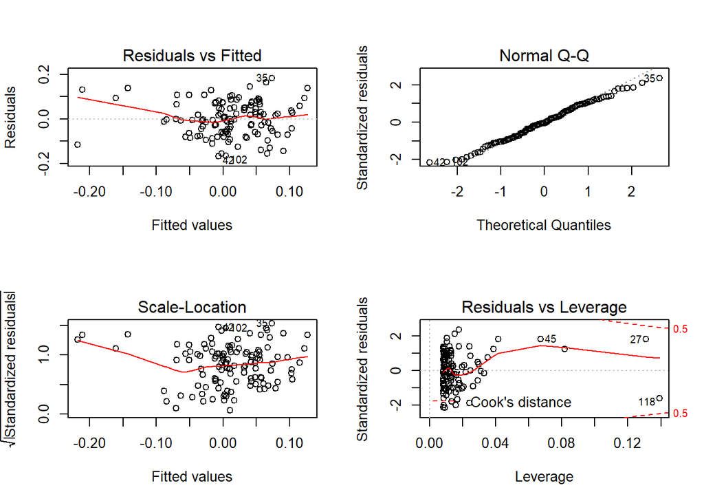

```r
par(mfrow = c(2,2))
plot(ols)
```

График **«Residuals vs Fitted»** помогает уловить возможные нелинейные зависимости между регрессором и объясняемой переменной. В «хорошем» случае мы ждем картинку с остатками, равномерно рассеянными вдоль горизонтальной прямой. В нашем случае несколько выбиваются наблюдения с отрицательной рыночной премией.

График **«Normal Q – Q»** позволяет визуально оценить нормальность распределения остатков. Эталоном здесь является пунктирная прямая. На графике функция распределения остатков нашей модели «похожа» на нормальную :)

График **«Scale – Location»** дает возможность «на глаз» оценить равную дисперсию остатков регресии и проверить наличие гетероскедастичности. За исключением немногочисленных наблюдений с отрицательной рыночной премией, в нашем случае предположение о гомоскедастичности (одинаковой дисперсии) остатков кажется верным.

График **«Residuals vs Leverage»** помогает выявить «влиятельные наблюдения» с высоким «воздействием» (high leverage). Это такие наблюдения, которые имеют нетипичные для выборки значения, но исключение которых может значительно повлиять на оценки коэффициентов модели. На графике они располагаются справа, за границами, обозначенными красной пунктирной линией (расстояние Кука).

Теперь построим $90\%$-й доверительный интервал для параметров модели.

```r
confint(ols, level = 0.9)
```

```
##                         5 %       95 %
## (Intercept)    -0.006683687 0.01718942
## market_premium  0.674382048 1.02191711
```

И заодно проверим гипотезу о равенстве коэффициента при регрессоре единице.

```r
linearHypothesis(ols, c("market_premium = 1"))
```

```
## Linear hypothesis test
##
## Hypothesis:
## market_premium = 1
##
## Model 1: restricted model
## Model 2: motor_premium ~ market_premium
##
##   Res.Df     RSS Df Sum of Sq      F Pr(>F)
## 1    119 0.73900
## 2    118 0.72608  1  0.012915 2.0989 0.1501
```

Видим, что на любом разумном уровне значимости она не отвергается.

Теперь посмотрим на остатки регрессии :) Протестируем их на нормальность с помощью теста Харке – Бера.

$$H_{0}: S = 0, K = 3,$$
где S — коэффициент асимметрии (Skewness), K — коэффициент эксцесса (Kurtosis)

```r
jarque.bera.test(resid(ols))
```

```
##
##  Jarque Bera Test
##
## data:  resid(ols)
## X-squared = 1.7803, df = 2, p-value = 0.4106
```

И заодно посмотрим на результаты теста Шапиро – Уилка.

$$H_{0}: \epsilon_{i} \sim N(\mu,\sigma^2)$$

```r
shapiro.test(resid(ols))
```

```
##
##  Shapiro-Wilk normality test
##
## data:  resid(ols)
## W = 0.99021, p-value = 0.5531
```

Оба теста указывают на нормальность распределения остатков.

Получим предсказания модели для обучаемой выборки.

```r
fitval = fitted(ols)
```

```r
set.seed(7)
new_data = tibble(market_premium = rnorm(10, mean = 0.01,
                                         sd = 0.1))
yhat = predict(ols, newdata = new_data, se = TRUE)
yhat$fit
```

```
##            1            2            3            4            5
##  0.207727133 -0.087769779 -0.045152029 -0.021234248 -0.068593258
##            6            7            8            9           10
## -0.066609148  0.077187768  0.003814809  0.026682011  0.199477263
```